# FACEBOOK use analysis

[Rui Pei](https://www.asc.upenn.edu/people/rui-pei)

2020-07-19

```r
rm(list = ls())
suppressPackageStartupMessages(library(ggplot2))
suppressPackageStartupMessages(library(tidyverse))
suppressPackageStartupMessages(library(plyr))
suppressPackageStartupMessages(library(dplyr))
suppressPackageStartupMessages(library(knitr))
suppressPackageStartupMessages(library(kableExtra))
suppressPackageStartupMessages(library(ggpubr))
suppressPackageStartupMessages(library(pander))
suppressPackageStartupMessages(library(jtools))
# suppressPackageStartupMessages(library(stringr))
# suppressPackageStartupMessages(library(broom.mixed))
# suppressPackageStartupMessages(library(sjPlot))
# suppressPackageStartupMessages(library(huxtable))
# suppressPackageStartupMessages(library(ggstance))
```

```r
pd <- position_dodge(0.3) # move them .05 to the left and right

# Multiple plot function
#
# ggplot objects can be passed in ..., or to plotlist (as a list of ggplot objects)
# - cols:   Number of columns in layout
# - layout: A matrix specifying the layout. If present, 'cols' is ignored.
#
# If the layout is something like matrix(c(1,2,3,3), nrow=2, byrow=TRUE),
# then plot 1 will go in the upper left, 2 will go in the upper right, and
# 3 will go all the way across the bottom.
#
multiplot <- function(..., plotlist=NULL, file, cols=1, layout=NULL) {
  library(grid)

  # Make a list from the ... arguments and plotlist
  plots <- c(list(...), plotlist)

  numPlots = length(plots)

  # If layout is NULL, then use 'cols' to determine layout
  if (is.null(layout)) {
    # Make the panel
    # ncol: Number of columns of plots
    # nrow: Number of rows needed, calculated from # of cols
    layout <- matrix(seq(1, cols * ceiling(numPlots/cols)),
                    ncol = cols, nrow = ceiling(numPlots/cols))
  }

 if (numPlots==1) {
    print(plots[[1]])

  } else {
    # Set up the page
    grid.newpage()
    pushViewport(viewport(layout = grid.layout(nrow(layout), ncol(layout))))

    # Make each plot, in the correct location
    for (i in 1:numPlots) {
      # Get the i,j matrix positions of the regions that contain this subplot
      matchidx <- as.data.frame(which(layout == i, arr.ind = TRUE))

      print(plots[[i]], vp = viewport(layout.pos.row = matchidx$row,
                                      layout.pos.col = matchidx$col))
    }
  }
}
numericcharacters <- function(x) {
  !any(is.na(suppressWarnings(as.numeric(x)))) & is.character(x)
}

scale1 <- function(x) scale(x)[,1]

construct_coef_df = function(dvs,df){
  fhab_mds = lapply(dvs, function(x) {
    lm(substitute(i ~ fhab + study_t + scanner_t, list(i = as.name(x))), data = df)
})
  fhab_sums = lapply(fhab_mds, summary)

  femo_mds = lapply(dvs, function(x) {
      lm(substitute(i ~ femo + study_t + scanner_t , list(i = as.name(x))), data = df)
  })
  femo_sums = lapply(femo_mds, summary)

  fconnected_mds = lapply(dvs, function(x) {
      lm(substitute(i ~ fconnected + study_t + scanner_t , list(i = as.name(x))), data = df)
  })
  fconnected_sums = lapply(fconnected_mds, summary)

  fhab_betas = c()
  femo_betas = c()
  fconnected_betas = c()
  fhab_se = c()
  femo_se = c()
  fconnected_se = c()
  for (i in c(1:length(dvs))){
    fhab_betas = c(fhab_betas,fhab_sums[[i]]$coefficients[2,1])
    femo_betas = c(femo_betas,femo_sums[[i]]$coefficients[2,1] )
    fconnected_betas = c(fconnected_betas,fconnected_sums[[i]]$coefficients[2,1] )
    fhab_se = c(fhab_se, fhab_sums[[i]]$coefficients[2,2])
    femo_se = c(femo_se, femo_sums[[i]]$coefficients[2,2])
    fconnected_se = c(fconnected_se, fconnected_sums[[i]]$coefficients[2,2])
  }

  coef_df = data.frame("IV" = c(rep("Habitual FB use", length(dvs)), rep("Emotional FB use", length(dvs)),
                                rep("FB connectedness", length(dvs))),
                       "DV" = c(dvs,dvs, dvs),
                       "beta" = c(fhab_betas, femo_betas, fconnected_betas),
                       "se" = c(fhab_se, femo_se,fconnected_se))
  coef_df = coef_df %>%
  mutate(IV = factor(coef_df$IV, levels=c("Habitual FB use", "Emotional FB use", "FB connectedness")))
  return(coef_df)
}

plot_coef_df = function(coef_dv){
  g1 = ggplot(coef_df, aes(x=DV, y=beta, colour=IV)) +
    geom_errorbar(aes(ymin= beta-1.96*se, ymax= beta+1.96*se), width=.1, position=pd) +
    geom_point(position=pd) + theme_pubr()  +
   geom_hline(yintercept=0, linetype="dashed",
                color = "grey", size=1) +
  rotate_x_text(45)
  # g1 = ggplot(coef_df, aes(x=DV, y=beta, colour=IV)) +
  #   geom_errorbar(aes(ymin= beta-1.96*se, ymax= beta+1.96*se), width=.1, position=pd) +
  #   geom_point(position=pd) + theme_pubr() + #+
  # scale_color_manual(values = c("Habitual FB use" = "dodgerblue", "Emotional FB use" = "forestgreen"))
  #  geom_hline(yintercept=0, linetype="dashed",
  #               color = "grey", size=1) +
  # rotate_x_text(45)
  return(g1)
}

construct_coef_df_iri = function(dvs,df){
  mds1 = lapply(dvs, function(x) {
    lm(substitute(i ~ IRI_Perspective_Taking + study_t + scanner_t, list(i = as.name(x))), data = df)
})
  sums1 = lapply(mds1, summary)

  mds2 = lapply(dvs, function(x) {
    lm(substitute(i ~ IRI_Fantasy + study_t + scanner_t, list(i = as.name(x))), data = df)
})
  sums2 = lapply(mds2, summary)

  mds3 = lapply(dvs, function(x) {
    lm(substitute(i ~ IRI_Empathic_Concern + study_t + scanner_t, list(i = as.name(x))), data = df)
})
  sums3 = lapply(mds3, summary)

  mds4 = lapply(dvs, function(x) {
    lm(substitute(i ~ IRI_Personal_Distress + study_t + scanner_t, list(i = as.name(x))), data = df)
})
  sums4 = lapply(mds4, summary)

  betas1 = c()
  betas2 = c()
  betas3 = c()
  betas4 = c()
  se1 = c()
  se2 = c()
  se3 = c()
  se4 = c()
  for (i in c(1:length(dvs))){
    betas1 = c(betas1,sums1[[i]]$coefficients[2,1])
    betas2 = c(betas2,sums2[[i]]$coefficients[2,1])
    betas3 = c(betas3,sums3[[i]]$coefficients[2,1])
    betas4 = c(betas4,sums4[[i]]$coefficients[2,1])
    se1 = c(se1, sums1[[i]]$coefficients[2,2])
    se2 = c(se2, sums2[[i]]$coefficients[2,2])
    se3 = c(se3, sums3[[i]]$coefficients[2,2])
    se4 = c(se4, sums4[[i]]$coefficients[2,2])
  }

  coef_df = data.frame("IV" = c(rep("Perspective taking", length(dvs)),
                                rep("Fantasy", length(dvs)),
                                rep("Empathic concern", length(dvs)),
                                rep("Personal distress", length(dvs))),
                       "DV" = c(dvs,dvs,dvs,dvs),
                       "beta" = c(betas1, betas2,betas3,betas4),
                       "se" = c(se1, se2,se3,se4))
  coef_df = coef_df
  return(coef_df)
}

plot_coef_iri = function(coef_dv){
  g1 = ggplot(coef_df, aes(x=DV, y=beta, colour=IV)) +
    geom_errorbar(aes(ymin= beta-1.96*se, ymax= beta+1.96*se), width=.1, position=pd) +
    geom_point(position=pd) + theme_pubr()  +
   geom_hline(yintercept=0, linetype="dashed",
                color = "grey", size=1) +
  rotate_x_text(45)
  return(g1)
}

corstar <- function(x, y = NULL, use = "pairwise", method = "pearson", round = 3, row.labels, col.labels, ...) {

  require(psych)

  ct <- corr.test(x, y, use, method)    # calculate correlation
  r <- ct$r                             # get correlation coefs
  p <- ct$p                             # get p-values

  stars <- ifelse(p < .001, "***", ifelse(p < .01, "** ", ifelse(p < .05, "*  ", "   "))) # generate significance stars

  m <- matrix(NA, nrow = nrow(r) * 2, ncol = ncol(r) + 1) # create empty matrix

  rlab <- if(missing(row.labels)) rownames(r) else row.labels # add row labels
  clab <- if(missing(col.labels)) {
    if(is.null(colnames(r)))
      deparse(substitute(y))
    else
      colnames(r)
  } else {
    col.labels # add column labels
  }

  rows <- 1:nrow(m)                     # row indices
  cols <- 2:ncol(m)                     # column indices

  odd <- rows %% 2 == 1                 # odd rows
  even <- rows %% 2 == 0                # even rows
  m[odd, 1] <- rlab                     # add variable names
  m[even, 1] <- rep("", sum(even))      # add blank

  m[odd, cols] <- paste(format(round(r, round), nsmall = round, ...), stars, sep = "")     # add r coefs
  m[even, cols] <- paste("(", format(round(p, round), nsmall = round, ...), ")", sep = "") # add p-values

  colnames(m) <- c(" ", clab)           # add colnames
  m                                     # return matrix
}
```

```r
path =  "~/Box Sync/CurrentProjects_Penn/TPS12_BART/99_fomo/github/"
setwd(path)
## socialMedia data
socialMedia = read.csv(paste0(path, '0_facebook/tps2_facebook.csv'),na.strings=c("","NA"), stringsAsFactors = FALSE)[-1,]

socialMedia = socialMedia %>%
  mutate(TPS_ID = as.factor(TPS_ID)) %>%
  mutate_if(is.character,as.numeric) %>%
  mutate(fhab = rowMeans(.[,10:19], na.rm = FALSE),
         femo = rowMeans(.[c(8,9,20:39)], na.rm = FALSE),#20:39 ## include the two "feel connected" questions in Emotional FB use.
         fconnected = rowMeans(.[c(8,9)], na.rm = FALSE),
         femopost = rowMeans(.[c(20:39)], na.rm = FALSE),
         TPS_ID = as.character(TPS_ID)) %>%
  select(TPS_ID, fhab, femo,fconnected,femopost )


cyber = read.csv(paste0(path, '0_cyberball/cyberball_roi.csv'), stringsAsFactors = FALSE)

age = read.csv(paste0(path, '0_surveys/tps12_scanner_study_age.csv'), stringsAsFactors = FALSE) %>%
  select(TPS_ID, age, study_t, scanner_t)



iri = read.csv(paste0(path, '0_surveys/iri_tps12.csv'), stringsAsFactors = FALSE)
iri = iri %>%
  mutate(IRI_mean = rowMeans(select(iri, starts_with("IRI_")), na.rm = FALSE))


nts = read.csv(paste0(path, '0_surveys/nts.csv'), stringsAsFactors = FALSE)

df = cyber %>%
  left_join(socialMedia, by = "TPS_ID") %>%
  left_join(age, by = "TPS_ID") %>%
  left_join(iri, by = "TPS_ID") %>%
  left_join(nts, by = "TPS_ID")


# Remove NAs
df = df %>% drop_na(fhab,femo, NTS_Belongingness,
                    NTS_SelfEsteem, NTS_Control,
                    NTS_MeaningfulExistence, study_t, scanner_t,
                    IRI_Perspective_Taking, IRI_Fantasy,
                    IRI_Empathic_Concern, IRI_Personal_Distress,
                    fconnected)

df = df[-which(df$TPS_ID == "TPS1P0009"),] # participant excluded due to movement

write.csv(df, "~/Downloads/facebook.csv", row.names = FALSE)

df$Scan_ID
```

```
##  [1] "110726ss"      "110725bb"      "110730zb"      "110814gb"
##  [5] "110814ld"      "110731te"      "110805jl"      "110815jg"
##  [9] "110820aq"      "110824ks"      "110812jd"      "110827dt"
## [13] "110925ml"      "110918ms"      "110924pl"      "111008jg"
## [17] "111030me"      "111030am"      "111029jg"      "110623jr"
## [21] "110725pr"      "110722cr"      "120731ta"      "120714mm"
## [25] "120714bl"      "120801lh"      "120729oc"      "120812ah"
## [29] "120831dl"      "120815sa"      "120826so"      "120828kz"
## [33] "120831nw"      "ebf10dis00033" "ebf10dis00035" "ebf10dis00038"
## [37] "ebf10dis00039" "ebf10dis00045" "ebf10dis00048" "ebf10dis00049"
## [41] "ebf10dis00050" "ebf10dis00053" "ebf10dis00055" "ebf10dis00056"
## [45] "ebf10dis00058" "ebf10dis00061" "ebf10dis00062" "ebf10dis00063"
## [49] "ebf10dis00064" "ebf10dis00065" "ebf10dis00067" "ebf10dis00069"
## [53] "ebf10dis00072" "ebf10dis00074" "ebf10dis00076" "ebf10dis00078"
## [57] "ebf10dis00079" "ebf10dis00080"
```

# 1. Participants

We include 58 participants in this report.

# 2. Data description

## Habitual FB use.

1 - Strongly disagree 7 - Strongly agree

1. Using Facebook is something I do automatically.
2. Using Facebook is something I do without meaning to do it.
3. Using Facebook is something I do without thinking.
4. Using Facebook is something I start doing before I realize I’m doing it.
5. Using Facebook is something that would require effort not to do it.
6. Using Facebook is something I do without having to consciously remember.
7. Using Facebook is something that belongs to my daily routine.
8. Using Facebook is something I would find hard not to do.
9. Using Facebook is something I have no need to think about doing.
10. Using Facebook is something that’s typically “me”.

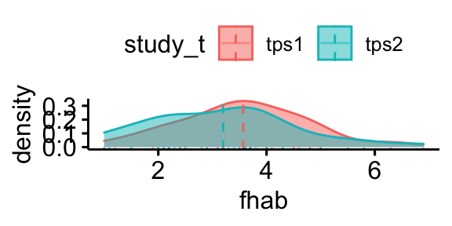

```r
ggdensity(df, x = "fhab",
   add = "mean", rug = TRUE,
   color = "study_t", fill = "study_t")
```

## Emotional FB use.

1. I feel connected to my friends when I use Facebook.
2. I feel connected to my family members when I use Facebook.

I get an urge to post on Facebook from my computer or phone the moment when … 3. something makes me feel amused  
4. something makes me feel surprised 5. something makes me feel awed 6. something makes me feel loved 7. something makes me feel proud  
8. something makes me feel excited  
9. something makes me feel grateful 10. something makes me feel happy  
11. something makes me feel inspired  
12. something makes me feel confident  
13. something makes me feel angry  
14. something makes me feel nervous 15. something makes me feel awkward 16. something makes me feel stressed  
17. something makes me feel jealous 18. something makes me feel lonely  
19. something makes me feel scared  
20. something makes me feel upset  
21. something makes me feel ashamed 22. something makes me feel guilty

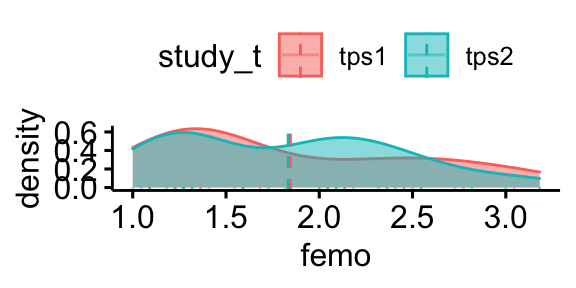

```r
ggdensity(df, x = "femo",
   add = "mean", rug = TRUE,
   color = "study_t", fill = "study_t")
```

## ROIS

Scrit to obtain the ROI values at [jupyter hub](https://fmrisrv2.asc.upenn.edu/user/rpei@asc.upenn.edu/notebooks/socialMedia/SPM_firstLevelModel/extract_ROIs_vijayakumar_rois_20200127.ipynb#).

```r
roi_names = colnames(df)[c(3:20,23)]
source = c("functional ROI",
           "functional ROI",
           "functional ROI",
           "functional ROI",
           "Dufour et al., 2013","Dufour et al., 2013","Dufour et al., 2013",
           "Dufour et al., 2013","Dufour et al., 2013","Dufour et al., 2013",
           "Dufour et al., 2013",
           "Vijayakumar et al., 2017","Vijayakumar et al., 2017",
           "Vijayakumar et al., 2017","Vijayakumar et al., 2017",
           "Vijayakumar et al., 2017","Vijayakumar et al., 2017",
           "Vijayakumar et al., 2017","Vijayakumar et al., 2017")
img_folder = '/Users/Rui/Box Sync/CurrentProjects_Penn/TPS12_BART/99_fomo/data/cyberball/ROIs/png/'
imgs = paste0(img_folder, roi_names, '.png')

rois = data.frame("name" = roi_names, "source" = source, "image" = imgs)


rois %>%
  # mutate(
  #   image %>% pander::pandoc.image.return()
  #   ) %>%
  select(-image) %>%
  pander()
```

| name | source |
| --- | --- |
| saxe_combined_mask | functional ROI |
| dACC_anatomical_mask | functional ROI |
| subacc_roi_mask | functional ROI |
| rInsula_roi_mask | functional ROI |
| lInsula_roi_mask | Dufour et al., 2013 |
| functional_combined_roi_mask | Dufour et al., 2013 |
| dmpfc_roi_mask | Dufour et al., 2013 |
| mmpfc_roi_mask | Dufour et al., 2013 |
| vmpfc_roi_mask | Dufour et al., 2013 |
| mpfc_roi_mask | Dufour et al., 2013 |
| precuneus_roi_mask | Dufour et al., 2013 |
| lTpj_roi_mask | Vijayakumar et al., 2017 |
| rTpj_roi_mask | Vijayakumar et al., 2017 |
| rSts_roi_mask | Vijayakumar et al., 2017 |
| ns_ment_mask | Vijayakumar et al., 2017 |
| ns_ment_clust1_mask | Vijayakumar et al., 2017 |
| ns_ment_clust2_mask | Vijayakumar et al., 2017 |
| ns_ment_clust3_mask | Vijayakumar et al., 2017 |
| ns_ment_clust6_mask | Vijayakumar et al., 2017 |

## IRI

**Perspective taking**

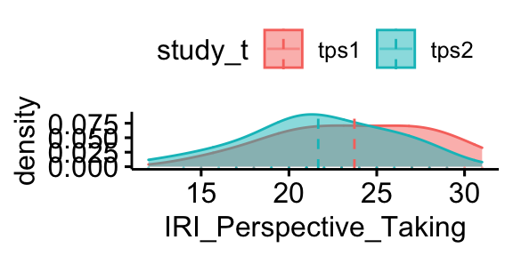

```r
ggdensity(df, x = "IRI_Perspective_Taking",
   add = "mean", rug = TRUE,
   color = "study_t", fill = "study_t")
```

[figure not shown]

```r
ggdensity(df, x = "IRI_Personal_Distress",
   add = "mean", rug = TRUE,
   color = "study_t", fill = "study_t")
```

**Empathic concern**

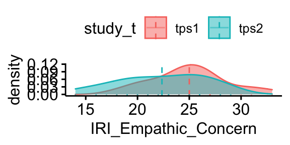

```r
ggdensity(df, x = "IRI_Empathic_Concern",
   add = "mean", rug = TRUE,
   color = "study_t", fill = "study_t")
```

**Fantasy**

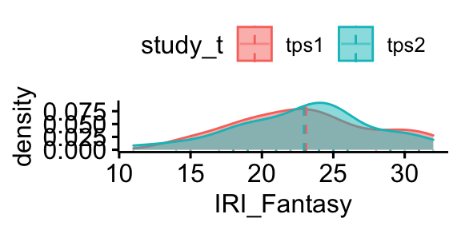

```r
ggdensity(df, x = "IRI_Fantasy",
   add = "mean", rug = TRUE,
   color = "study_t", fill = "study_t")
```

## Need threat scale

**Lower scores indicate greater distress**

**Belongingness**

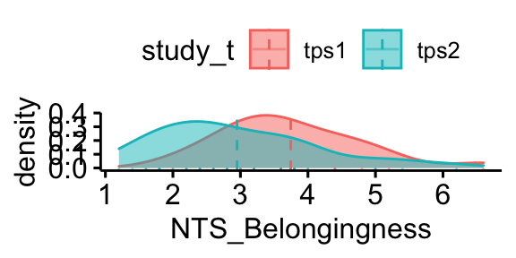

```r
ggdensity(df, x = "NTS_Belongingness",
   add = "mean", rug = TRUE,
   color = "study_t", fill = "study_t")
```

**Self esteem**

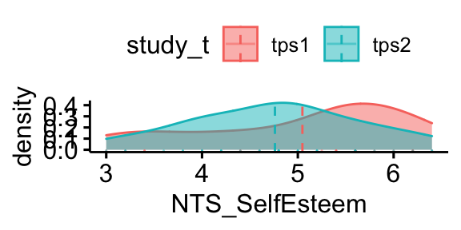

```r
ggdensity(df, x = "NTS_SelfEsteem",
   add = "mean", rug = TRUE,
   color = "study_t", fill = "study_t")
```

**Control**

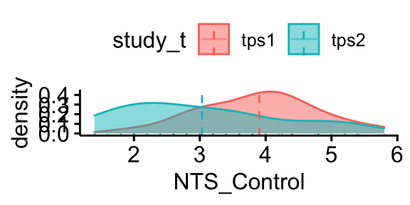

```r
ggdensity(df, x = "NTS_Control",
   add = "mean", rug = TRUE,
   color = "study_t", fill = "study_t")
```

**MeaningfulExistence**

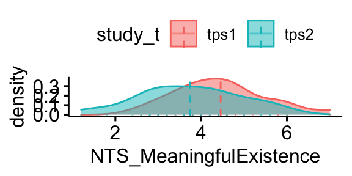

```r
ggdensity(df, x = "NTS_MeaningfulExistence",
   add = "mean", rug = TRUE,
   color = "study_t", fill = "study_t")
```

# 3. Correlation matrix (IRI + NTS)

Stars indicate signiciant correlation, and (x) indicate p values.

```r
m = corstar(df[,c("IRI_Perspective_Taking","IRI_Fantasy",
              "IRI_Empathic_Concern","IRI_Personal_Distress",
              "NTS_Belongingness","NTS_SelfEsteem",
              "NTS_Control","NTS_MeaningfulExistence")])

m[c(1,2),2] = ""
m[c(1:4),3] = ""
m[c(1:6),4] = ""
m[c(1:8),5] = ""
m[c(1:10),6] = ""
m[c(1:12),7] = ""
m[c(1:14),8] = ""

df_m = as.data.frame(m[,1:8])
rownames(df_m) = NULL
kable(df_m) %>%
  kable_styling(bootstrap_options = c("striped", "hover", "condensed", "responsive"))
```

|  | IRI_Perspective_Taking | IRI_Fantasy | IRI_Empathic_Concern | IRI_Personal_Distress | NTS_Belongingness | NTS_SelfEsteem | NTS_Control |
| --- | --- | --- | --- | --- | --- | --- | --- |
| IRI_Perspective_Taking |  |  |  |  |  |  |  |
| IRI_Fantasy | 0.208 |  |  |  |  |  |  |
|  | (0.117) |  |  |  |  |  |  |
| IRI_Empathic_Concern | 0.482*** | 0.287* |  |  |  |  |  |
|  | (0.000) | (0.029) |  |  |  |  |  |
| IRI_Personal_Distress | -0.152 | 0.088 | 0.196 |  |  |  |  |
|  | (0.256) | (0.511) | (0.141) |  |  |  |  |
| NTS_Belongingness | 0.299* | 0.044 | 0.175 | -0.212 |  |  |  |
|  | (0.023) | (0.743) | (0.190) | (0.109) |  |  |  |
| NTS_SelfEsteem | 0.093 | 0.236 | -0.004 | -0.218 | 0.460*** |  |  |
|  | (0.487) | (0.074) | (0.978) | (0.101) | (0.000) |  |  |
| NTS_Control | 0.122 | 0.165 | 0.000 | -0.084 | 0.656*** | 0.595*** |  |
|  | (0.363) | (0.216) | (0.998) | (0.533) | (0.000) | (0.000) |  |
| NTS_MeaningfulExistence | 0.337** | 0.279* | 0.185 | -0.078 | 0.688*** | 0.429*** | 0.670*** |
|  | (0.010) | (0.034) | (0.165) | (0.561) | (0.000) | (0.001) | (0.000) |

# 4. Linking FB use with self-report

```r
# ## scale the IVs and DVs
# df = df %>%
#   mutate_at(c(3:26,29:37), scale1)
```

## IRI

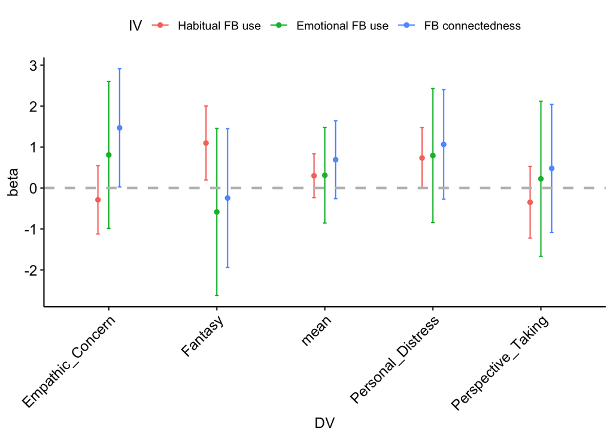

```r
dvs = c("IRI_Perspective_Taking","IRI_Fantasy",
                   "IRI_Empathic_Concern","IRI_Personal_Distress", "IRI_mean")

coef_df = construct_coef_df(dvs, df) %>%
  mutate(DV = gsub("IRI_", "", DV))

plot_coef_df(coef_dv)
```

## NTS

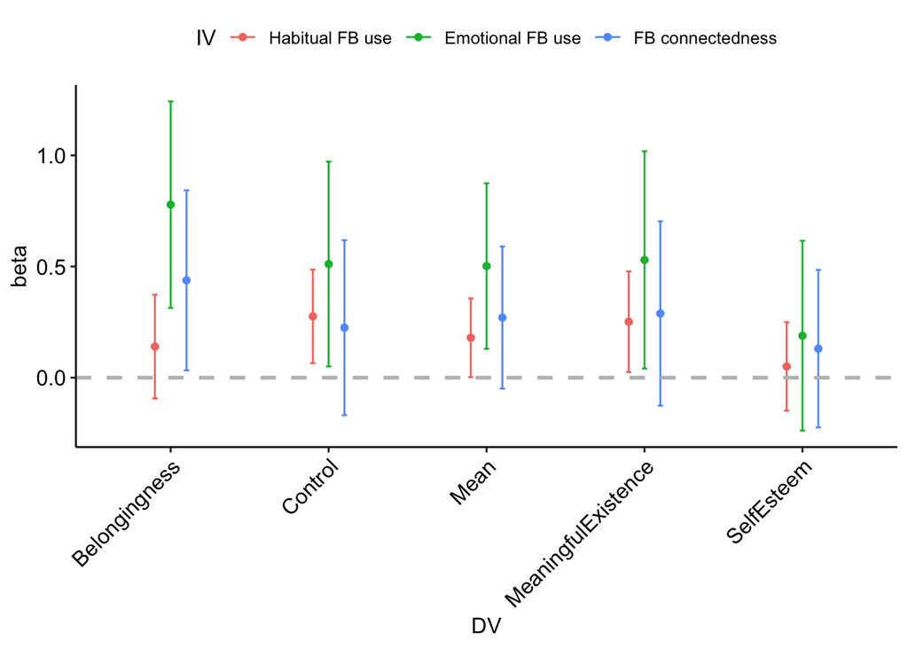

```r
dvs = c("NTS_Belongingness","NTS_SelfEsteem",
        "NTS_Control", "NTS_MeaningfulExistence","NTS_Mean")

coef_df = construct_coef_df(dvs, df) %>%
  mutate(DV = gsub("NTS_", "", DV))
plot_coef_df(coef_dv)
```

```r
md = lm(NTS_Belongingness ~ fconnected + study_t+  age , data = df)
summary(md)
```

```
##
## Call:
## lm(formula = NTS_Belongingness ~ fconnected + study_t + age,
##     data = df)
##
## Residuals:
##     Min      1Q  Median      3Q     Max
## -1.8815 -0.7188 -0.3276  0.7194  2.8690
##
## Coefficients:
##             Estimate Std. Error t value Pr(>|t|)
## (Intercept)  -3.1039     6.5344  -0.475   0.6367
## fconnected    0.4298     0.1926   2.231   0.0299 *
## study_ttps2  -0.6427     0.3076  -2.089   0.0414 *
## age           0.3340     0.3844   0.869   0.3887
## ---
## Signif. codes:  0 '***' 0.001 '**' 0.01 '*' 0.05 '.' 0.1 ' ' 1
##
## Residual standard error: 1.103 on 54 degrees of freedom
## Multiple R-squared:  0.1897, Adjusted R-squared:  0.1447
## F-statistic: 4.213 on 3 and 54 DF,  p-value: 0.009484
```

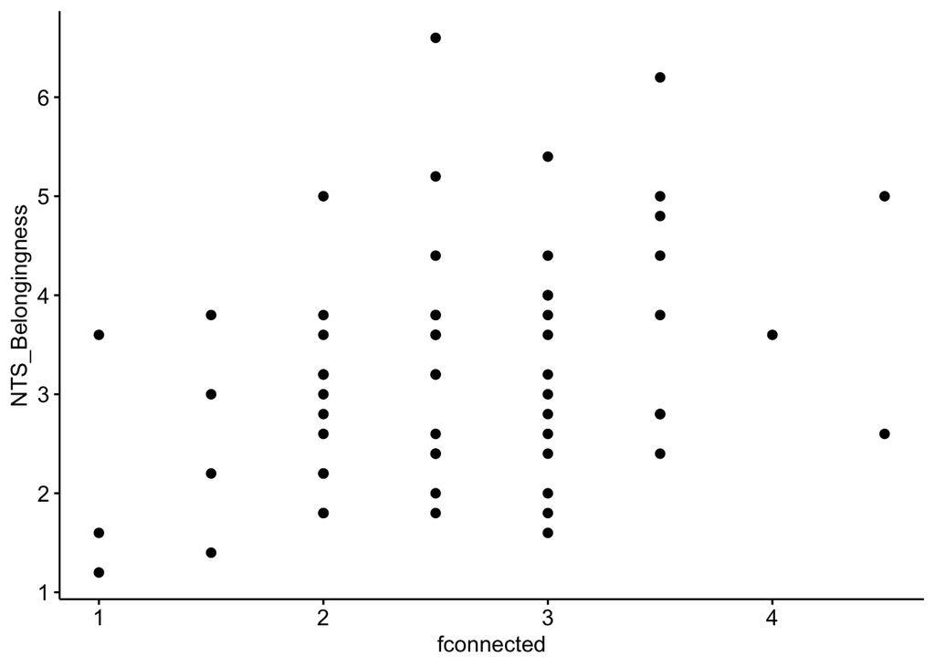

```r
ggscatter(df, "fconnected", "NTS_Belongingness")
```

# 5. Linking FB use with neural data

## Functional ROIS

Functional ROIs (n = 59)

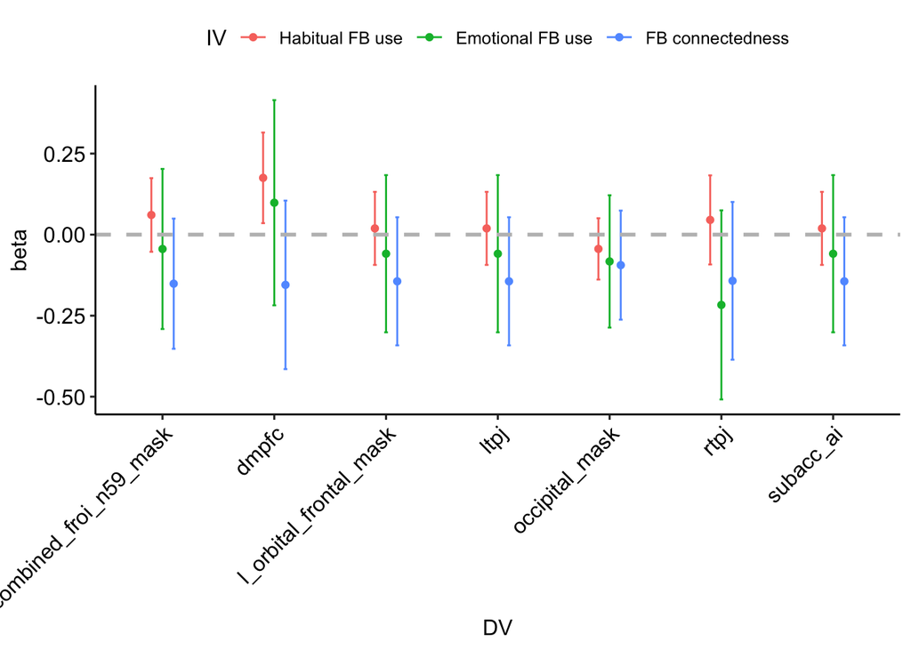

```r
dvs = c("rtpj_froi_mask","ltpj_froi_mask","l_orbital_frontal_mask",
        "subacc_ai_froi_mask", "dmpfc_froi_mask","occipital_mask","combined_froi_n59_mask")

coef_df = construct_coef_df(dvs, df) %>%
  mutate(DV = gsub("_froi_mask", "", DV))

ggplot(coef_df, aes(x=DV, y=beta, colour=IV)) +
    geom_errorbar(aes(ymin= beta-1.96*se, ymax= beta+1.96*se), width=.1, position=pd) +
    geom_point(position=pd) + theme_pubr()  +
   geom_hline(yintercept=0, linetype="dashed",
                color = "grey", size=1) +
  rotate_x_text(45)
```

```r
dvs = c("subacc_roi_mask","rInsula_roi_mask",
        "lInsula_roi_mask", "functional_combined_roi_mask")

coef_df = construct_coef_df(dvs, df) %>%
  mutate(DV = gsub("_roi_mask", "", DV))
plot_coef_df(coef_dv)
```

[output not shown]

## Dufour mentalzing meta-analytic ROIS

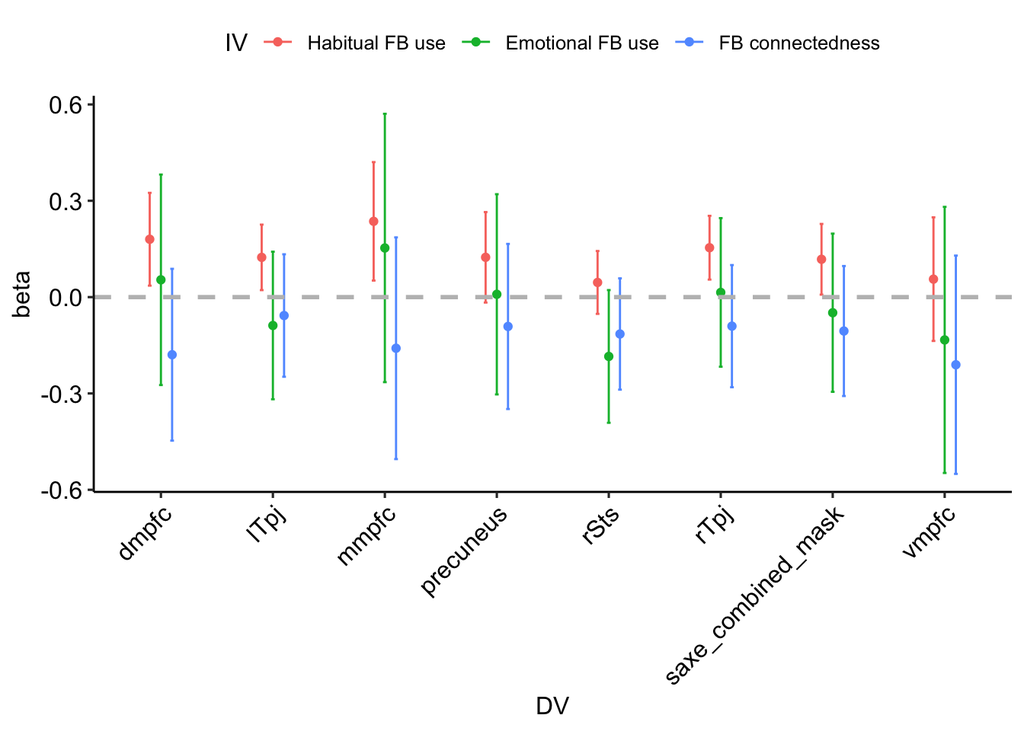

```r
dvs = c("vmpfc_roi_mask","dmpfc_roi_mask","mmpfc_roi_mask", "precuneus_roi_mask",            "lTpj_roi_mask","rTpj_roi_mask" ,"rSts_roi_mask",
        "saxe_combined_mask")

coef_df = construct_coef_df(dvs, df) %>%
  mutate(DV = gsub("_roi_mask", "", DV))
plot_coef_df(coef_dv)
```

```r
# md = lm(saxe_combined_mask ~ fhab +age + study_t + scanner_t, data = df)
# summ(md, digits = 3)
#
# ggscatter(df, "fhab", "dmpfc_roi_mask")
```